# Fertility, Infant Mortality, and Socioeconomic Disparities in the U.S.

Author

Alice Xu, Miao Qi

Published

March 12, 2025

# 1 Abstract

This study comprehensively examines the racial, socioeconomic, and policy influences on **fertility (2016 - 2023)** and **infant mortality (2003 - 2023)** rates in the United States. Utilizing a multifaceted analytical approach, including Principal Component Analysis (PCA), regression models, and fixed-effects modeling, the research identifies key determinants of fertility and infant mortality across different demographic and socioeconomic groups.

The analysis reveals **significant disparities in birth rates** based on maternal age, education level, marital status, and Medicaid coverage, with higher fertility rates observed among **younger, less educated, and unmarried women**. Conversely, higher educational attainment and Medicaid coverage exhibit mixed influences on fertility patterns. The study also highlights persistent racial disparities in infant mortality, with **non-Hispanic Black populations** experiencing significantly higher mortality rates compared to other racial groups, underscoring systemic inequities in healthcare access and socioeconomic stability. The fixed-effects model demonstrates high predictive accuracy for future fertility rates, confirming the stability of these socioeconomic variables over time. These findings provide critical insights into the complex interplay of demographic, economic, and policy-related factors shaping reproductive health outcomes in the U.S.

Finally, the study underscores the **need for targeted public health policies to address educational disparities**, improve access to family planning resources, and reduce healthcare inequities, particularly among high-risk racial groups. Future research should further explore the complex interactions between demographic and policy factors while integrating granular data on healthcare interventions to enhance the precision of predictive models and inform more effective public health strategies.

# 2 Introduction

Fertility rates and infant mortality serve as fundamental indicators of public health and socioeconomic well-being in a society. These metrics are shaped by a complex interplay of demographic, economic, and policy-related factors.Fertility rates may influence by maternal age, education, income levels, and access to reproductive healthcare etc. A cross-national research highlights that fertility rates tend to decline with increasing education levels, greater access to contraception, and higher GDP per capita, while religiosity is often associated with higher fertility (Götmark & Andersson, 2020). At the same time, the World Health Organization (WHO) defines infant mortality rate as the probability of a child dying between birth and one year of age per 1,000 live births, and it reflects disparities in healthcare accessibility, socioeconomic conditions, and racial inequities in maternal health outcomes (WHO, 2023). Understanding the relationship between these factors provides crucial insights into long-term population dynamics in the United States.

The U.S. has witnessed significant variations in fertility and infant mortality across different racial groups. Despite overall reductions in infant mortality rates over the past decades, racial and ethnic disparities persist, particularly affecting Black infants. Research indicates that Black infants are more than twice as likely to die within their first year of life compared to White infants, highlighting deep-rooted inequities in maternal and infant health outcomes (Rossen, 2016).

This study aims to comprehensively analyze fertility and infant mortality data across U.S. states from 2003 to 2023. By utilizing statistical modeling techniques such as Principal Component Analysis (PCA), regression models, and fixed-effects modeling, we seek to explore the correlations between socioeconomic determinants, including education level, marital status, medication aid coverage, and race, and their impacts on fertility and infant mortality rates. Identifying the key socioeconomic drivers will contribute to a deeper understanding of health disparities.

```r
fertility_data <- read_csv("fertility_data.csv")
mortality_data <- read_csv("infant_mortality_biannual_data.csv")
```

Above imported datasets provide comprehensive view of fertility and infant mortality trends in the United States over a decade, offering valuable insights into demographic and health disparities. It includes birth records categorized by maternal characteristics such as age, education level, marital status, and insurance coverage. Additionally, it captures infant mortality rates in different races of America.

With these data, this analysis is going to answer how these factors, including race, education level, martial status and more, impact on fertility and infant mortality rates across different states in the United States. Additionally, this report will analyze on long-term trends and potential future changes on fertility and infant mortality considering dempgraphic shifts in the U.S..

# 3 Exploratory Analysis

## 3.1 Data Cleaning

### 3.1.1 Select Variable

To analyze fertility and mortality trends, we carefully selected key variables that capture **demographic, socioeconomic, and regional influences**.

For *fertility analysis*, we included **geographic and temporal identifiers** (state, year, and bmcode) to track regional trends. Birth counts are examined across **age groups** (15-24, 25-34, 35-44) and **educational attainment** (no high school, high school graduate, some college, college graduate) to explore reproductive patterns and the role of education. We also consider **marital status** and **insurance coverage** to assess disparities between births within and outside of marriage, as well as Medicaid coverage. Additionally, **race/ethnicity** data (Non-Hispanic Black, Non-Hispanic White, Hispanic, and Other) provide insights into demographic fertility trends. To standardize birth rates, we incorporate **population data** segmented by age, education, marital status, and insurance coverage.

For *mortality analysis*, we apply a similar approach, including **geographic and temporal identifiers** for tracking changes over time. Infant mortality counts are analyzed by **race/ethnicity** to understand disparities, while **cause of death classifications** help distinguish between congenital conditions, neonatal complications, and other contributing factors.

### 3.1.2 Remove Missing Values

Handling missing values is an important part in data wranling and further analysis, making the data more interpretable and comprehensible. The code employs the `na.omit()` function to remove any observations containing missing values from both the **fertility dataset** (`fertility_sub`) and the **mortality dataset** (`mortality_sub`). Eliminating missing values helps prevent potential biases and inaccuracies in statistical analyses, such as incorrect rate calculations or distortions in correlation and regression modeling.

Number of Missing Values in Each Dataset

| Dataset | Missing_Values |
| --- | --- |
| Fertility Data Clean | 0 |
| Mortality Data Clean | 0 |

### 3.1.3 Aggregating Annual Fertility and Mortality Data

To analyze long-term trends, we aggregated fertility and mortality data at the **state-year level** for consistency and comparability, prepared for further studies.

**Fertility Data Processing (df_annual)**:

We computed the **birth rate per 1,000 individuals** by summing birth and population counts across demographic groups (age, education, and marital status). Additionally, the **crude fertility rate**, representing the overall birth rate per state and year, was calculated to provide a broader measure of fertility trends.

**Mortality Data Processing (df_mor)**

Similarly, infant mortality rates were standardized by aggregating total births and deaths at the state-year level. The **mortality rate per 1,000** live births was then computed to ensure a uniform measure of mortality trends across states and years.

Annual Aggregated Fertility Data

| State | Year | Birth Rate (15-24) | Birth Rate (25-34) | Birth Rate (35-44) | Birth Rate (No HS) | Birth Rate (HS) | Birth Rate (Some College) | Birth Rate (College) | Birth Rate (Married) | Birth Rate (Unmarried) | Birth Rate (Medicaid) | Crude Fertility Rate |
| --- | --- | --- | --- | --- | --- | --- | --- | --- | --- | --- | --- | --- |
| Alabama | 2016 | 10.566875 | 16.55354 | 3.507480 | 9.048463 | 10.601331 | 10.30312 | 10.955217 | 14.68493 | 7.560537 | 7.669484 | 10.333433 |
| Alabama | 2017 | 10.432364 | 16.49480 | 3.621500 | 8.228745 | 10.201461 | 11.11140 | 11.111164 | 14.76995 | 7.712010 | 7.534037 | 10.323344 |
| Alabama | 2018 | 10.073494 | 16.23436 | 3.655816 | 8.427239 | 10.205721 | 10.68733 | 10.457895 | 13.84498 | 7.755503 | 7.346999 | 10.126525 |
| Alabama | 2019 | 10.169359 | 16.51526 | 3.710695 | 9.031958 | 9.896266 | 11.33734 | 10.333838 | 13.49507 | 8.179719 | 7.210719 | 10.270882 |
| Alabama | 2020 | 9.156172 | 16.26258 | 3.755746 | 8.518620 | 9.806958 | 10.53723 | 9.825650 | 13.02116 | 7.776092 | 6.973309 | 9.818649 |
| Alabama | 2021 | 8.853321 | 16.49500 | 3.840090 | 8.197397 | 9.930053 | 10.36905 | 9.989538 | 13.62446 | 7.403572 | 6.655498 | 9.801543 |

Annual Aggregated Mortality Data

| State | Year | Infant Mortality Rate |
| --- | --- | --- |
| Alabama | 2003 | 8.715072 |
| Alabama | 2004 | 8.670812 |
| Alabama | 2005 | 9.395729 |
| Alabama | 2006 | 9.030238 |
| Alabama | 2007 | 9.891365 |
| Alabama | 2008 | 9.481610 |

## 3.2 Visualization of Overall Trend

### 3.2.1 Fertility Data: Trends in birth rates vs. different education levels from 2016 to 2023

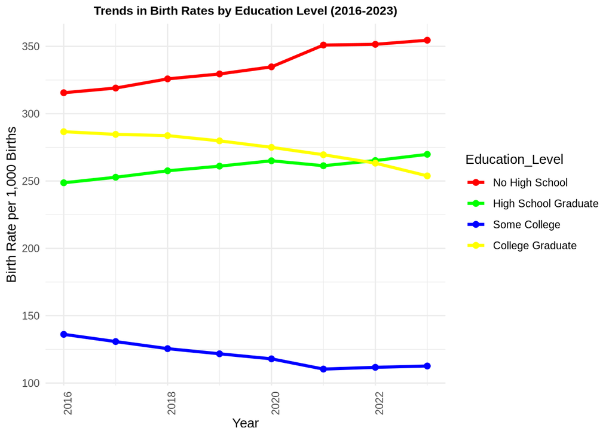

The trends in birth rates by **education level** from 2016 to 2023 reveal distinct patterns. Individuals **without a high school diploma** exhibit the highest birth rates, with a steady increase, particularly after 2020. This suggests that lower educational attainment may be associated with higher fertility rates, possibly due to socioeconomic factors such as limited access to higher education and family planning resources. In contrast, birth rates among **college graduates** have gradually declined, crossing below those of high school graduates around 2022, which may indicate shifting priorities toward career advancement or delayed family planning. The `Some College` group consistently reports the lowest birth rates, with a continued decline over time, reinforcing the idea that increased education levels often correlate with lower fertility. Meanwhile, **high school graduates** show a slight upward trend, suggesting that many in this group may achieve financial stability earlier, enabling them to support families. These patterns highlight the strong connection between education and fertility decisions, with higher educational attainment generally aligning with lower birth rates.

### 3.2.2 Fertility Data: Fertility rates by state and age group

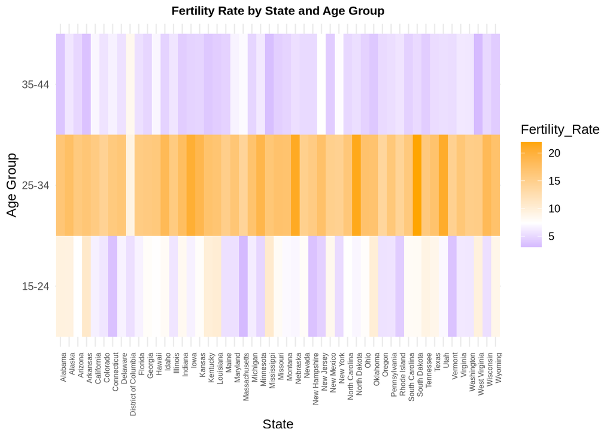

The heatmap illustrates fertility rate variations **across states and age groups**. Women **aged 25-34** exhibit the *highest fertility rates*, as indicated by the darker orange hues. This aligns with broader trends where individuals in this age range often achieve economic stability and make family planning decisions. In contrast, fertility rates among younger women **(15-24)** and older women **(35-44)** tend to be lower, shown by lighter shades. This may reflect delayed childbirth due to education and career aspirations among younger women, while older women might experience biological or financial constraints that influence fertility decisions. The state-level variations further suggest potential differences in socioeconomic conditions, healthcare access, and cultural norms affecting birth rates.

### 3.2.3 Fertility Data: Crude Fertility Rate Trend by Region (2016-2023) & Mortality Data: Crude Mortality Rate Trend by Region (2003-2023)

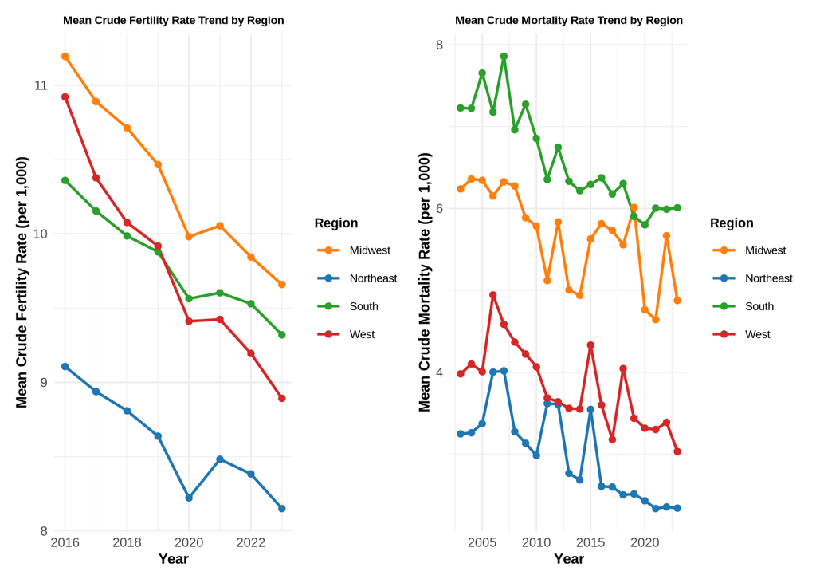

Fertility and mortality rates have shown a **consistent decline across all regions**, reflecting broader demographic and socioeconomic trends. The **Midwest** has historically exhibited the highest fertility rates, while the **Northeast** maintains the lowest, likely influenced by urbanization and career prioritization. *Mortality rates* vary more, with the **South** showing the highest levels, whereas the **Northeast and West** maintain lower rates, potentially linked to healthcare access and socioeconomic conditions.

A **sharp drop** in fertility and mortality rates around **2020** suggests significant external disruptions. This decline is likely tied to the **COVID-19 pandemic**, which introduced economic uncertainty, reduced healthcare access, and altered reproductive choices. Lockdowns and job losses may have led to delayed family planning, while increased health risks disproportionately affected vulnerable populations, contributing to shifts in birth and death rates. Additionally, changes in healthcare utilization, including delayed medical interventions and altered prenatal care, may have influenced these trends. This period represents a crucial turning point in population dynamics, highlighting how external crises can shape demographic behaviors.

**Fertility and mortality rates have both declined over time**, shaped by demographic shifts, healthcare improvements, and socioeconomic factors. Fertility rates are highest in the **Midwest and South** and lowest in the **Northeast**, with a notable drop around 2020, likely due to **external disruptions** such as COVID-19. Mortality rates have also decreased, driven by medical advancements and public health initiatives, though the **South** maintains the highest rates due to chronic disease prevalence and healthcare disparities. A **sharp decline between 2010 and 2015**, especially in the Midwest and South, aligns with medication aid `Medicaid` expansion and disease prevention efforts. Despite overall declines, regional fluctuations suggest that **external factors** continue to influence these trends.

# 4 PCA Analysis

## 4.1 Standardization

Before performing PCA, all numeric variables in the fertility dataset are standardized to **ensure consistency in scale**. Standardization transforms these variables to have a mean of zero and a standard deviation of one, preventing features with larger ranges from disproportionately influencing the analysis. This process enhances the interpretability and comparability of principal components, allowing for a more balanced representation of the underlying data structure.

```r
numeric_vars <- sapply(fertility_data_clean, is.numeric)
fertility_data_clean[numeric_vars] <- scale(fertility_data_clean[numeric_vars])
```

The mortality dataset is not included in the PCA analysis due to its limited number and category of variables, which primarily consist of race-related attributes. Since PCA identifies the most significant features contributing to variance, applying it to a dataset with only a few categorical or race-based variables would result in all available variables being selected as top contributors. This would provide little meaningful differentiation among features and reduce the effectiveness of dimensionality reduction. The results of the PCA will be visualized and later compared with the mortality data to explore potential relationships between fertility patterns and mortality rates across different groups.

## 4.2 Perform PCA

### 4.2.1 Corrlation Plot

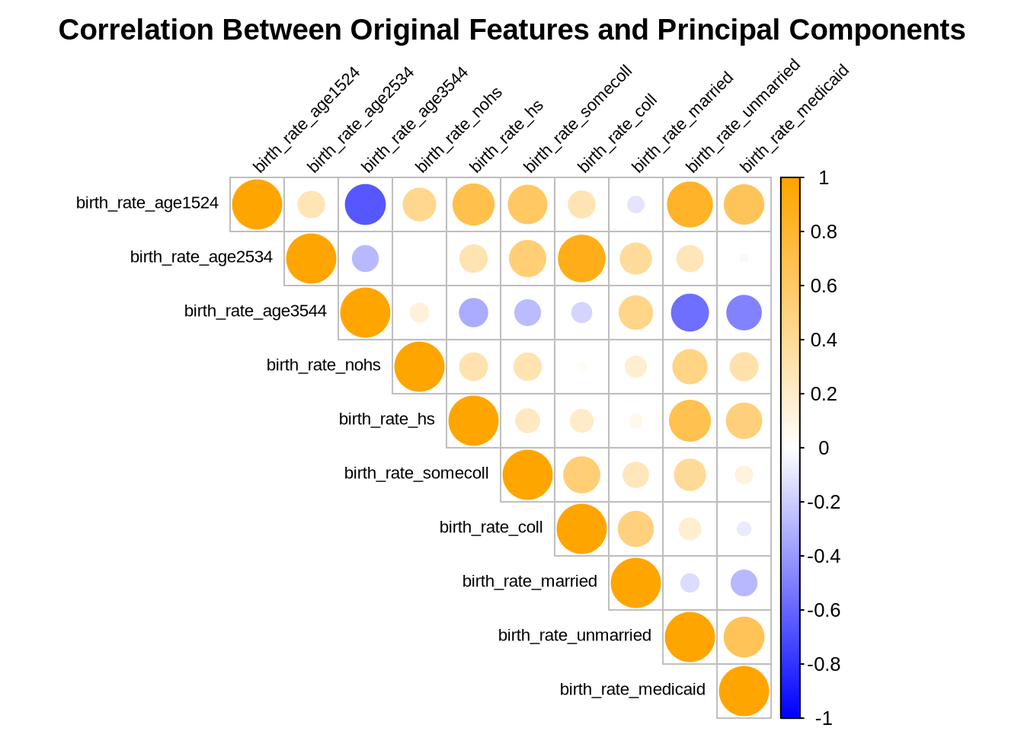

The **25–34 age group** presents mixed correlations, reflecting a more complex role in fertility trends. Education-related birth rate features **(no high school, high school, some college, and college)** show weak correlations, suggesting their influence is more distributed.

Overall, age-related birth rates strongly shape principal components, while education and marital status contribute in subtler ways.

### 4.2.2 PVE & cPVE Representation

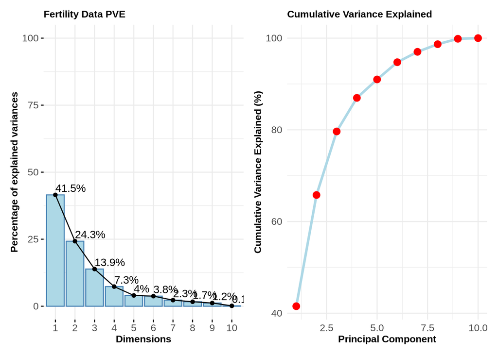

The **Percentage of Explained Variance (PVE)** plot illustrates the contribution of each principal component to the total variance. The first principal component (PC1) captures **41.5%** of the variance, followed by PC2 with **24.3%** and PC3 with **13.9%**. The variance contribution decreases for subsequent components, indicating that most of the dataset’s structure is captured by the first few PCs. This helps determine how many principal components are necessary for a meaningful representation.

The **Cumulative Variance Explained (cPVE)** plot shows how variance accumulates as more principal components are included. The curve rises sharply at first and flattens after four to five components, indicating that these few PCs explain the majority of the dataset’s variability. This suggests that dimensionality reduction beyond this point yields diminishing returns, making the first few components the most informative.

### 4.2.3 Loading Vectors Interpretation

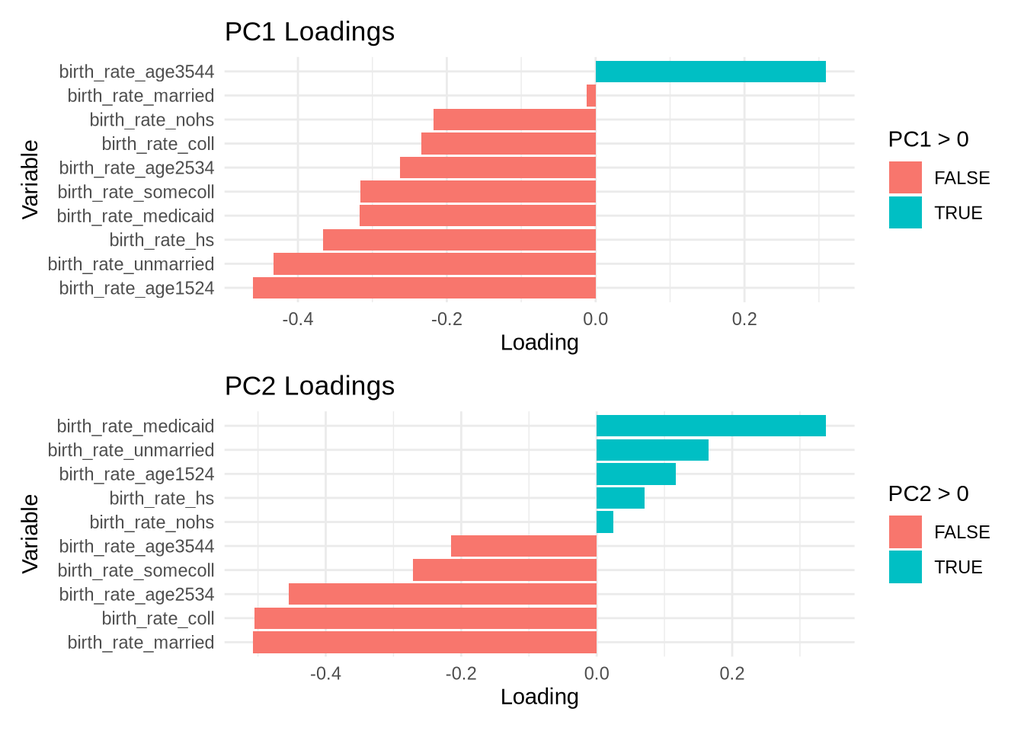

**PC1 Loadings: Socioeconomic and Age-Based Fertility Trends**

Most variables show negative loadings, particularly birth rates for **younger age groups (15–24, 25–34)**, unmarried individuals, and those on Medicaid. This suggests that higher fertility among younger, lower-income, or unmarried populations is inversely related to PC1. The only positive loading is for `birth_rate_age3544`, indicating that higher birth rates at older ages are associated with an increase in PC1. **PC1 likely represents a socioeconomic fertility axis**, where higher values align with delayed childbirth and greater stability (e.g., married or older mothers), while lower values indicate younger, economically disadvantaged fertility patterns.

# 5 Regression Analysis

## 5.1 Linear Regression of Fertility Rate

### 5.1.1 Build Model

Based on the PCA analysis, we know that marriage, education, medication aid and the age of the mother (6 variables) are the top important features in influencing the fertility rate of the US. In this section, we will delve into these variables to see how each of them related to the fertility rate with a linear regression.

```r
df_lm <- df_annual |>
  select(birth_rate_age1524, birth_rate_unmarried, birth_rate_hs, birth_rate_medicaid,
         birth_rate_somecoll, birth_rate_age3544, crude_fert_rate)

model3 <- lm(crude_fert_rate ~ birth_rate_age1524 + birth_rate_unmarried +
             birth_rate_hs + birth_rate_medicaid + birth_rate_somecoll + birth_rate_age3544,
             data = df_lm)
```

|  | Estimate | Std. Error | t value | Pr(>\|t\|) |
| --- | --- | --- | --- | --- |
| (Intercept) | 0.9825 | 0.3273 | 3.001 | 0.002857 |
| birth_rate_age1524 | 0.004028 | 0.03309 | 0.1217 | 0.9032 |
| birth_rate_unmarried | 0.1346 | 0.03515 | 3.829 | 0.0001495 |
| birth_rate_hs | 0.3055 | 0.02556 | 11.95 | 2.605e-28 |
| birth_rate_medicaid | -0.0466 | 0.01551 | -3.005 | 0.002828 |
| birth_rate_somecoll | 0.459 | 0.02624 | 17.49 | 4.022e-51 |
| birth_rate_age3544 | 0.08996 | 0.03127 | 2.877 | 0.004234 |

| Statistic | Value |
| --- | --- |
| Adjusted R² | 0.7926 |
| Overall p-value | < 2.2e-16 |

The regression model demonstrates a strong fit, with an **adjusted** $R^2$ of 0.7926, indicating that approximately 79.26% of the variance in the crude fertility rate is explained by the selected predictors. The **overall model p-value (< 2.2e-16)** confirms statistical significance, suggesting that at least one predictor meaningfully contributes to the model.

Among the predictors, **birth_rate_hs (0.3055) and birth_rate_somecoll (0.459)** exhibit the highest positive coefficients, indicating that higher fertility rates are strongly associated with individuals who have a high school or some college education. Additionally, **birth_rate_unmarried (0.1346) and birth_rate_age3544 (0.0899)** also show significant positive relationships with fertility rates, though to a lesser extent.

Conversely, **birth_rate_medicaid (-0.0466)** has a negative coefficient, suggesting that higher birth rates among Medicaid recipients are associated with lower overall fertility rates. This could reflect socioeconomic disparities affecting fertility patterns. Notably, **birth_rate_age1524 (p = 0.9032)** is not statistically significant, implying that birth rates among individuals aged 15–24 do not contribute meaningfully to the model.

### 5.1.2 Visualization of Regression Model

After fitting the regression model, the result shows that the all the top variables are important except `birth_rate_age1524`. For better understanding and interpretability, a regression visulizaiton is presented.

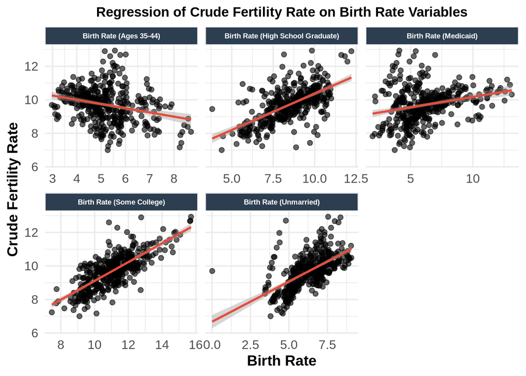

The scatter plots with regression lines illustrate the relationship between crude fertility rate and key birth rate variables identified through PCA and regression analysis.

The **birth rate for ages 35–44** exhibits a **negative** slope, indicating an inverse relationship between higher birth rates in this age group and overall fertility. This suggests that as older women’s birth rates increase, the crude fertility rate declines, possibly due to delayed childbirth trends and lower total birth counts in this group.

In contrast, **high school graduate birth rates** show a **positive slope**, meaning that higher birth rates among high school graduates correspond with increased overall fertility. This aligns with previous regression results, emphasizing **education level** as a significant factor in fertility patterns. Similarly, **birth rates among individuals with some college educatio**n demonstrate one of the strongest **positive correlations**, reinforcing that higher birth rates in this group contribute notably to overall fertility rates.

The **birth rate among Medicaid recipients** presents a slightly **positive** slope, suggesting a small increase in fertility as birth rates in this group rise. However, this trend contrasts with the negative coefficient in the regression model, implying that other socioeconomic factors, such as income level and healthcare access, may interact with Medicaid status in shaping fertility trends.

Lastly, **birth rates among unmarried women** also show a **positive slope**, indicating that as non-marital birth rates rise, overall fertility increases. This highlights the growing role of non-marital fertility in shaping total fertility trends in the U.S.

Overall, the visualization confirms that **age, marital status, and education levels** are key determinants of fertility trends. Education presents a complex role, with high school and some college education positively associated with fertility, while higher education’s impact remains unclear and may require further investigation.

### 5.1.3 How Races Correlated to Fertility and Mortality Rates?

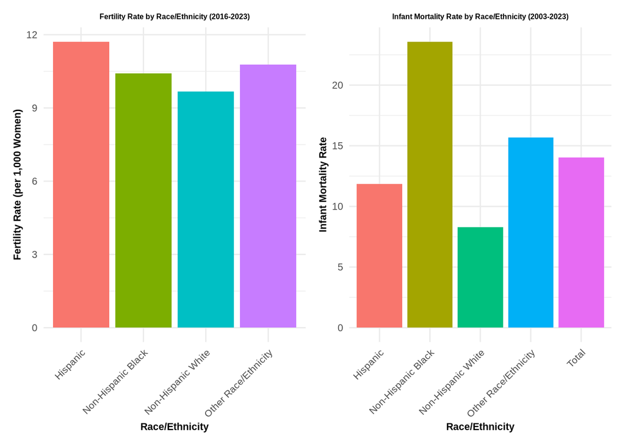

**Remark:** This analysis uses the raw fertility and mortality data, rather than the cleaned dataset, meaning missing values were not removed. The reason for retaining missing values is to avoid overrepresentation of complete cases, which may introduce bias in demographic trends. Removing missing values could distort the actual racial/ethnic distribution by disproportionately excluding certain groups with incomplete records.

# 6 Next Year Prediction: Fixed Effect Model

## 6.1 Model Training

```r
# Split train/test if you have enough years:
train_data <- filter(model_data, year <= 2020)
test_data  <- filter(model_data, year > 2020)

# Fit a linear model predicting next year's fertility
lm_model <- lm(next_year_fert ~ birth_rate_age3544 + birth_rate_unmarried +
               birth_rate_medicaid + birth_rate_hs + birth_rate_hs +
               birth_rate_somecoll + year + factor(state),
               data = train_data)
```

We first divided the dataset into training (<= 2020) and testing (> 2020) subsets based on the year variable. This ensures that the model is trained on past data and tested on future observations, simulating real-world forecasting. Then the model is trained to predict next_year_fert (next year’s fertility rate) using birth rate predictors (birth_rate_age3544, birth_rate_unmarried, birth_rate_medicaid, etc, and year) to capture time trends.

## 6.2 Regression Output & Error Rate

| Statistic | Value |
| --- | --- |
| Adjusted R² | 0.9644 |
| Overall p-value | < 2.2e-16 |

The regression results indicate a strong model fit for predicting next year’s fertility rate.

A**djusted** $R^2$ = 0.9644 suggests that 96.44% of the variance in the dependent variable (next_year_fert) is explained by the predictors included in the model.

**Overall p-value < 2.2e-16** means that the model as a whole is statistically significant, meaning that at least one of the predictors has a significant relationship with fertility rates. This confirms that the independent variables collectively contribute to explaining fertility rate variation.

```r
# Predict on the test set
preds <- predict(lm_model, newdata = test_data)

# Evaluate (e.g., RMSE)
rmse <- sqrt(mean((test_data$next_year_fert - preds)^2 , na.rm=TRUE))
cat("The RMSE of the model is:", rmse)
```

```
The RMSE of the model is: 0.2490876
```

The **RMSE value is 0.249**, which is a very low RMSE. Thus, the model performs well in predicting future fertility rates, reinforcing its reliability for forecasting.

Overall, the model provides a highly reliable framework for short-term fertility rate prediction, effectively utilizing historical trends and demographic factors. However, further refinement, such as incorporating additional socioeconomic indicators or nonlinear modeling techniques, could enhance predictive performance.

## 6.3 Model Diagnostic

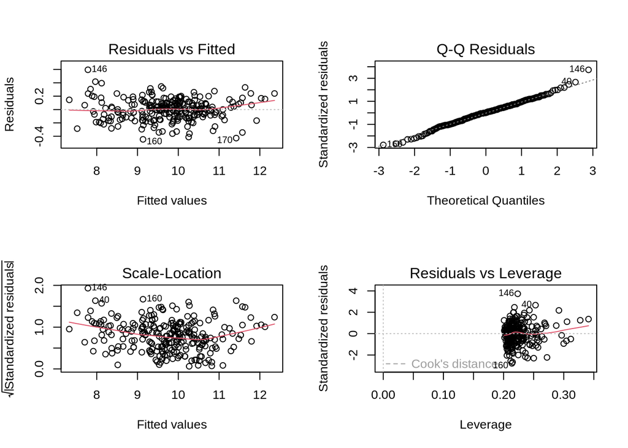

The diagnostic plots provide insights into the validity and assumptions of the regression model. The **Residuals vs. Fitted plot** shows that the residuals are randomly scattered around zero, indicating no clear pattern. This suggests that the assumption of homoscedasticity holds, meaning the variance of residuals remains consistent across fitted values.

The **Normal Q-Q plot** indicates that the residuals follow an approximately normal distribution, as most points align closely along the 45-degree reference line. This suggests that normality assumptions are largely satisfied, with only slight deviations at the tails.

The **Scale-Location plot** further supports the absence of heteroscedasticity, as standardized residuals are evenly spread across fitted values. The lack of strong patterns or systematic trends confirms that the residual variance remains stable.

Overall, the model diagnostics confirm that the regression model performs well, with no major violations of key assumptions. While the model meets the assumptions of homoscedasticity and normality, minor deviations and influential points suggest that further refinement could enhance robustness and predictive reliability.

# 7 Conclusion

This study presents a comprehensive analysis of **fertility and infant mortality rates** in the United States, examining key demographic, socioeconomic, and policy-related factors that influence these critical public health indicators. By leveraging statistical modeling techniques—including Principal Component Analysis (PCA), regression analysis, and fixed-effects modeling—this research identifies significant determinants of fertility and infant mortality across different racial and socioeconomic groups.

The findings shows clear **disparities in birth and infant mortality rates based on race, education level, marital status, and Medicaid coverage**. The regression analysis demonstrates that higher fertility rates are associated with lower education levels and unmarried status, whereas higher educational attainment and Medicaid coverage exhibit mixed influences on birth rates. Additionally, the fixed-effects model effectively predicts next-year fertility rates with high accuracy (Adjusted $R^2$ = 0.9644), confirming that these socioeconomic variables have a stable impact over time.

Importantly, the study underscores the **persistence of racial disparities in infant mortality rates**, with non-Hispanic Black populations experiencing significantly higher mortality rates compared to other racial groups. These disparities suggest systemic inequities in healthcare access, maternal health support, and socioeconomic stability that continue to shape reproductive health outcomes.

In conclusion, this study has improved our understanding of the complex links between socioeconomic characteristics, race, fertility, and infant mortality rates in the United States. The detected trends and inequalities can help inform evidence-based policymaking. For example, policies could be developed to promote access to education and family planning tools for those with lower levels of education in order to assist regulate fertility rates. Furthermore, initiatives to eliminate healthcare inequities, particularly in areas with high mortality rates and among high-risk racial groups, are critical. Future study might delve deeper into the intricate relationships between these elements, include more specific data on policy changes, and increase the accuracy of predictive models. This would contribute to more effective public health initiatives, resulting in better mother and newborn health outcomes across the country.

# 8 Reference

Data on births and population in the United States (2016 - 2023) [Dataset]. Centers for Disease Control and Prevention (CDC). Retrieved from https://www.cdc.gov/nchs/pressroom/sosmap/fertility_rate/fertility_rates.htm

Infant mortality data and births by category from 2003 - 2023.” Dataset. Retrieved [retrieval date], from https://www.cdc.gov/maternal-infant-health/infant-mortality/index.html

Götmark, F., Andersson, M. Human fertility in relation to education, economy, religion, contraception, and family planning programs. BMC Public Health 20, 265 (2020). https://doi.org/10.1186/s12889-020-8331-7

WHO. (2023). Infant Mortality Rate (IMR) - WHO Global Health Observatory. World Health Organization. Retrieved from https://www.who.int/data/gho/indicator-metadata-registry/imr-details/1#:~:text=Like%20under%2Dfive%20mortality%2C%20infant,live%2C%20including%20their%20health%20care.

Rossen LM, Khan D, Schoendorf KC. Mapping Geographic Variation in Infant Mortality and Related Black-White Disparities in the US. Epidemiology. 2016 Sep;27(5):690-6. doi: 10.1097/EDE.0000000000000509. PMID: 27196804; PMCID: PMC5378167.